# Trotterized Quantum Simulation of a Periodic Heisenberg Chain

We study the periodic anisotropic Heisenberg chain with a transverse X field,

$$H = \sum_{j=0}^{N-1}\left(J_x X_jX_{j+1}+J_yY_jY_{j+1}+J_zZ_jZ_{j+1}\right) + h_x\sum_{j=0}^{N-1}X_j$$

Default: $N=6,\ J_x=1.0,\ J_y=0.7,\ J_z=1.2,\ h_x=0.4$. Initial state $|\psi_0\rangle=|010101\rangle$ (qubit-0-first).

## Setup and Imports

```
Number of time points: 301
Initial state, qubit-0-last: |101010>
```

## Problem 1(a): Construct the Hamiltonian

Build the `SparsePauliOp` Hamiltonian, report the total number of Pauli terms, and identify terms introduced by the periodic boundary condition.

| Ordering | Description |
| --- | --- |
| `sequential` | Bond-by-bond: for each $(j, j\!+\!1)$ add XX, YY, ZZ in sequence |
| `even_odd` | Pauli-type major: all XX bonds (even then odd), then all YY bonds (even then odd), then all ZZ bonds |
| `even_odd_grouped` | Even then odd bonds; within each parity group: **all XX**, then **all YY**, then **all ZZ** |

`even_odd_grouped` places same-operator terms for non-overlapping qubit pairs consecutively (e.g. XX(0,1), XX(2,3), XX(4,5) in a row). Because these commute and act on disjoint qubits, the transpiler parallelises them into a single layer even at `optimization_level=0`.

**Qiskit Pauli-string convention**: the *rightmost* character corresponds to qubit 0. To place operator $P$ on qubit $j$ in an $N$-qubit system, set `chars[N-1-j] = P`.

```
N=6, LieTrotter k=1
  [depth]
```

| ordering | opt0 | opt1 | opt2 | opt3 |
| --- | --- | --- | --- | --- |
| sequential | 79 | 73 | 37 | 37 |
| even_odd | 27 | 23 | 22 | 22 |
| even_odd_grouped | 27 | 25 | 13 | 13 |

```
  [CX count]
```

| ordering | opt0 | opt1 | opt2 | opt3 |
| --- | --- | --- | --- | --- |
| sequential | 36 | 36 | 18 | 18 |
| even_odd | 36 | 36 | 36 | 36 |
| even_odd_grouped | 36 | 36 | 18 | 18 |

```
  [2Q depth]
```

| ordering | opt0 | opt1 | opt2 | opt3 |
| --- | --- | --- | --- | --- |
| sequential | 36 | 36 | 18 | 18 |
| even_odd | 12 | 12 | 12 | 12 |
| even_odd_grouped | 12 | 12 | 6 | 6 |

```
N=6, LieTrotter k=2
  [depth]
```

| ordering | opt0 | opt1 | opt2 | opt3 |
| --- | --- | --- | --- | --- |
| sequential | 158 | 145 | 73 | 73 |
| even_odd | 54 | 45 | 43 | 43 |
| even_odd_grouped | 54 | 49 | 25 | 25 |

```
  [CX count]
```

| ordering | opt0 | opt1 | opt2 | opt3 |
| --- | --- | --- | --- | --- |
| sequential | 72 | 72 | 36 | 36 |
| even_odd | 72 | 72 | 72 | 72 |
| even_odd_grouped | 72 | 72 | 36 | 36 |

```
  [2Q depth]
```

| ordering | opt0 | opt1 | opt2 | opt3 |
| --- | --- | --- | --- | --- |
| sequential | 72 | 72 | 36 | 36 |
| even_odd | 24 | 24 | 24 | 24 |
| even_odd_grouped | 24 | 24 | 12 | 12 |

```
N=6, SuzukiTrotter order=2 k=1
  [depth]
```

| ordering | opt0 | opt1 | opt2 | opt3 |
| --- | --- | --- | --- | --- |
| sequential | 158 | 145 | 67 | 67 |
| even_odd | 54 | 45 | 41 | 41 |
| even_odd_grouped | 54 | 49 | 19 | 19 |

```
  [CX count]
```

| ordering | opt0 | opt1 | opt2 | opt3 |
| --- | --- | --- | --- | --- |
| sequential | 72 | 72 | 33 | 33 |
| even_odd | 72 | 72 | 66 | 66 |
| even_odd_grouped | 72 | 72 | 27 | 27 |

```
  [2Q depth]
```

| ordering | opt0 | opt1 | opt2 | opt3 |
| --- | --- | --- | --- | --- |
| sequential | 72 | 72 | 33 | 33 |
| even_odd | 24 | 24 | 22 | 22 |
| even_odd_grouped | 24 | 24 | 9 | 9 |

```
N=6, SuzukiTrotter order=4 k=1
  [depth]
```

| ordering | opt0 | opt1 | opt2 | opt3 |
| --- | --- | --- | --- | --- |
| sequential | 790 | 721 | 307 | 307 |
| even_odd | 270 | 221 | 193 | 193 |
| even_odd_grouped | 270 | 241 | 67 | 67 |

```
  [CX count]
```

| ordering | opt0 | opt1 | opt2 | opt3 |
| --- | --- | --- | --- | --- |
| sequential | 360 | 360 | 153 | 153 |
| even_odd | 360 | 360 | 306 | 306 |
| even_odd_grouped | 360 | 360 | 99 | 99 |

```
  [2Q depth]
```

| ordering | opt0 | opt1 | opt2 | opt3 |
| --- | --- | --- | --- | --- |
| sequential | 360 | 360 | 153 | 153 |
| even_odd | 120 | 120 | 102 | 102 |
| even_odd_grouped | 120 | 120 | 33 | 33 |

[output not shown]

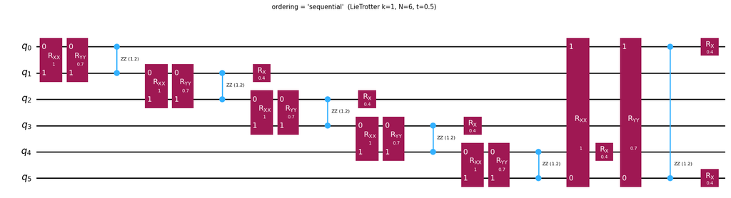

```
[even_odd]
```

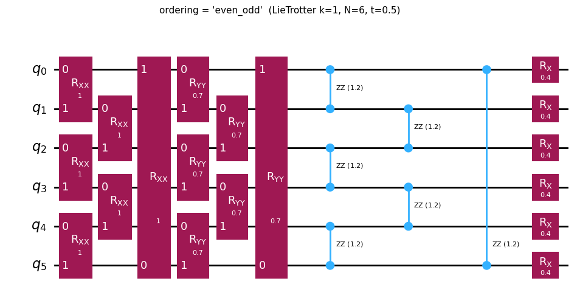

```
[even_odd_grouped]
```

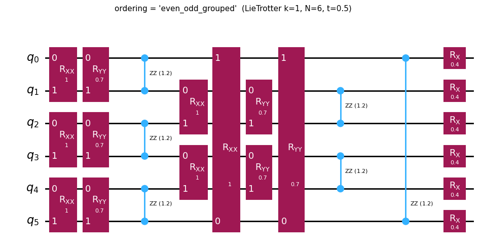

### 왜 even_odd (CX=36) 와 even_odd_grouped (CX=18) 는 다른가?

**even_odd** (type-major): 모든 XX → 모든 YY → 모든 ZZ 순서

| 순번 | even_odd | 순번 | even_odd_grouped |
| --- | --- | --- | --- |
| 1 | XX(0,1) | 1 | XX(0,1) |
| 2 | XX(2,3) | 2 | XX(2,3) |
| 3 | XX(4,5) | 3 | XX(4,5) |
| 4 | XX(1,2) | 4 | YY(0,1) |
| 5 | XX(3,4) | 5 | YY(2,3) |
| 6 | XX(5,0) | 6 | YY(4,5) |
| 7 | YY(0,1) | 7 | ZZ(0,1) |
| … | … | … | … |

#### CX 소거 조건

`RXX(q0,q1)` 회로는 `CX(q0,q1) → Rx(θ) → CX(q0,q1)` 구조이므로, 같은 qubit 쌍에 `RXX → RYY` 가 연속하면 경계 CX 두 개가 소거된다.

- **even_odd**: XX(0,1) (pos.1) 과 YY(0,1) (pos.7) 사이에 **XX(1,2)** 가 끼어있다. XX(1,2) 는 qubit 1 을 qubit (0,1) 과 공유 → XX(0,1) 뒤로 YY(0,1) 을 당길 수 없음. → CX 소거 불가 → CX = **36**
- **even_odd_grouped**: 짝수 레이어에서 XX(0,1) 바로 다음은 XX(2,3), XX(4,5). 이 bond 들은 qubits **{2,3}, {4,5}** — qubit 0,1 과 공유 없음 (disjoint). → 트랜스파일러가 YY(0,1) 을 XX(0,1) 바로 뒤로 이동 가능 → CX 소거 → CX = **18**

> **요약**: `even_odd_grouped` 가 `even_odd` 보다 회로 깊이와 CX 수가 적다. 짝수/홀수 레이어 내부에서 같은 Pauli 타입의 bond 들이 disjoint qubit 쌍이기 때문에

```
||U_even_odd - U_even_odd_grouped|| = 8.6833
두 유니터리 동일: False

||U_seq - U_eo ||  = 9.3322
||U_seq - U_eog||  = 8.6958
```

## Exact Reference Simulation

Since $N=6$, exact classical simulation via diagonalization is cheap. Pre-diagonalize $H$ and cache the eigenbasis expansion of $|\psi_0\rangle$ so that $e^{-iHt}|\psi_0\rangle$ can be evaluated in $O(2^N)$ time per time point.

```
Computing exact states over all time points...
Done. Z1 range: [-1.000, 0.562]
```

## Problem 1(b-c): Product-formula circuits and resource counts

Construct circuits using `PauliEvolutionGate` with:

- `LieTrotter(reps=k)`
- `SuzukiTrotter(order=2, reps=k)`
- `SuzukiTrotter(order=4, reps=k)`

for $k = 1,2,3$. Transpile into `{cx, u3, u1}` and report resource counts.

```
Resource counts  t=0.5  ordering='even_odd_grouped'  opt_level=0
```

| setting | depth | gate count | two-qubit gates | one-qubit gates |
| --- | --- | --- | --- | --- |
| LT_k1 | 27 | 108 | 36 | 72 |
| ST2_k1 | 54 | 215 | 72 | 143 |
| ST4_k1 | 270 | 1075 | 360 | 715 |
| LT_k2 | 54 | 216 | 72 | 144 |
| ST2_k2 | 108 | 430 | 144 | 286 |
| ST4_k2 | 540 | 2150 | 720 | 1430 |
| LT_k3 | 81 | 324 | 108 | 216 |
| ST2_k3 | 162 | 645 | 216 | 429 |
| ST4_k3 | 810 | 3225 | 1080 | 2145 |

```
Resource counts  t=0.5  ordering='even_odd_grouped'  opt_level=1
```

| setting | depth | gate count | two-qubit gates | one-qubit gates |
| --- | --- | --- | --- | --- |
| LT_k1 | 25 | 96 | 36 | 60 |
| ST2_k1 | 49 | 186 | 72 | 114 |
| ST4_k1 | 241 | 906 | 360 | 546 |
| LT_k2 | 49 | 186 | 72 | 114 |
| ST2_k2 | 97 | 366 | 144 | 222 |
| ST4_k2 | 481 | 1806 | 720 | 1086 |
| LT_k3 | 73 | 276 | 108 | 168 |
| ST2_k3 | 145 | 546 | 216 | 330 |
| ST4_k3 | 721 | 2706 | 1080 | 1626 |

```
Resource counts  t=0.5  ordering='even_odd_grouped'  opt_level=2
```

| setting | depth | gate count | two-qubit gates | one-qubit gates |
| --- | --- | --- | --- | --- |
| LT_k1 | 13 | 56 | 18 | 38 |
| ST2_k1 | 19 | 87 | 27 | 60 |
| ST4_k1 | 67 | 300 | 99 | 201 |
| LT_k2 | 25 | 113 | 36 | 77 |
| ST2_k2 | 31 | 138 | 45 | 93 |
| ST4_k2 | 127 | 570 | 189 | 381 |
| LT_k3 | 37 | 168 | 54 | 114 |
| ST2_k3 | 43 | 192 | 63 | 129 |
| ST4_k3 | 187 | 837 | 279 | 558 |

```
Resource counts  t=0.5  ordering='even_odd_grouped'  opt_level=3
```

| setting | depth | gate count | two-qubit gates | one-qubit gates |
| --- | --- | --- | --- | --- |
| LT_k1 | 13 | 56 | 18 | 38 |
| ST2_k1 | 19 | 87 | 27 | 60 |
| ST4_k1 | 67 | 300 | 99 | 201 |
| LT_k2 | 25 | 113 | 36 | 77 |
| ST2_k2 | 31 | 138 | 45 | 93 |
| ST4_k2 | 127 | 570 | 189 | 381 |
| LT_k3 | 37 | 168 | 54 | 114 |
| ST2_k3 | 43 | 192 | 63 | 129 |
| ST4_k3 | 187 | 837 | 279 | 558 |

## Problem 1(d-f): State and local-observable errors

$$\epsilon_{state}(t)=1-|\langle\psi_{exact}(t)|\psi_{PF}(t)\rangle|^2$$

$$\epsilon_O(t)=|\langle O\rangle_{exact}(t)-\langle O\rangle_{PF}(t)|$$

```
Computing Trotter errors for all settings and time points...
  LT_k1 ...
```

```
done
  ST2_k1 ...
```

```
done
  ST4_k1 ...
```

```
done
  LT_k2 ...
```

```
done
  ST2_k2 ...
```

```
done
  ST4_k2 ...
```

```
done
  LT_k3 ...
```

```
done
  ST2_k3 ...
```

```
done
  ST4_k3 ...
```

```
done
```

|  | setting | time | state_infidelity | Z1_error | Z0Z1_error |
| --- | --- | --- | --- | --- | --- |
| 0 | LT_k1 | 0.00 | 4.440892e-16 | 4.440892e-16 | 4.440892e-16 |
| 1 | LT_k1 | 0.05 | 6.148790e-04 | 7.934004e-05 | 1.554761e-04 |
| 2 | LT_k1 | 0.10 | 9.129806e-03 | 1.191192e-03 | 2.177023e-03 |
| 3 | LT_k1 | 0.15 | 4.075913e-02 | 5.408949e-03 | 8.682460e-03 |
| 4 | LT_k1 | 0.20 | 1.080959e-01 | 1.458590e-02 | 1.875640e-02 |

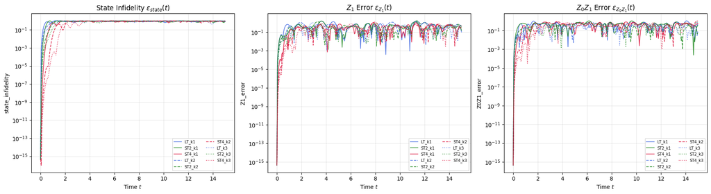

## Problem 1(g): Discussion — accuracy vs. circuit depth

**Same repetition number $k$:**  
ST4 > ST2 > LT in accuracy because higher-order formulas cancel more Trotter error terms.

**Trade-off:**  
Increasing $k$ reduces the per-step time $\Delta t = t/k$, which shrinks the Trotter error but linearly increases circuit depth and two-qubit gate count, raising hardware noise.

### Circuit Resources (N=12, `even_odd_grouped`, opt_level=3, t=0.5)

[output not shown]

**관찰:**

```
N=12, ordering='even_odd_grouped', opt=3
```

|  | Formula | k | depth | CX | 2Q_depth |
| --- | --- | --- | --- | --- | --- |
| 0 | LT | 1 | 13 | 36 | 6 |
| 1 | LT | 2 | 25 | 72 | 12 |
| 2 | LT | 3 | 37 | 108 | 18 |
| 3 | ST2 | 1 | 19 | 54 | 9 |
| 4 | ST2 | 2 | 31 | 90 | 15 |
| 5 | ST2 | 3 | 43 | 126 | 21 |
| 6 | ST4 | 1 | 67 | 198 | 33 |
| 7 | ST4 | 2 | 127 | 378 | 63 |
| 8 | ST4 | 3 | 187 | 558 | 93 |

Settings: $N=12$, $J_x=J_y=1.0$, $J_z=1.2$, $h_x=0$, initial state $|100000000000\rangle$, $t=1.0$.

Fill in your IBM credentials via `.env` or `QiskitRuntimeService.save_account()`.

```
Total Pauli terms: 48

Periodic-boundary terms (j -> 0 wrap-around):
       pauli  sites type  coeff  periodic_BC
XIIIIIIIIIIX (11,0)   XX    1.0         True
YIIIIIIIIIIY (11,0)   YY    1.0         True
ZIIIIIIIIIIZ (11,0)   ZZ    1.2         True
N=12 circuit built.
Ideal <Z_0> at t=1.0: 0.684564
```

## Problem 2(a): Exact autocorrelation

$$A(t) = \langle\psi_0|e^{-iHt}|\psi_0\rangle = \sum_n |\langle E_n|\psi_0\rangle|^2 e^{-iE_n t}$$

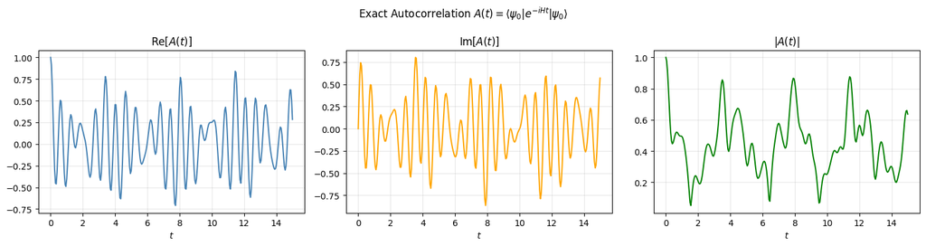

## Problem 2(b-c): Trotterized autocorrelation via Hadamard-test circuit

Construct a **Hadamard-test circuit** to estimate $$A_{PF}(t) = \langle\psi_0|\psi_{PF}(t)\rangle = \langle\psi_0|U_{PF}(t)|\psi_0\rangle.$$

Circuit structure ($N+1$ qubits, ancilla = $q_0$, system = $q_{1\ldots N}$):

$$\text{Re:}\quad |0\rangle_{\rm anc} \xrightarrow{H} \frac{|0\rangle+|1\rangle}{\sqrt{2}} \xrightarrow{\text{ctrl-}U_{PF}} \frac{|0\rangle|\psi_0\rangle + |1\rangle U_{PF}|\psi_0\rangle}{\sqrt{2}} \xrightarrow{H} \quad \Rightarrow \quad P(0)-P(1) = \operatorname{Re}(A_{PF})$$

$$\text{Im:}\quad \text{same but insert } S^\dagger \text{ on ancilla before final } H \quad \Rightarrow \quad P(0)-P(1) = \operatorname{Im}(A_{PF})$$

The key gate is `PauliEvolutionGate(H_spo, time=t, synthesis=...).control(1)`, which creates a controlled-$U_{PF}$ acting on qubits $0\ldots N$.

```
Hadamard-test verification against direct vdot:
    t    Re(direct)    Im(direct)      Re(HT)      Im(HT)     |error|
  0.0      1.000000      0.000000    1.000000    0.000000    0.00e+00
  0.5      0.071279     -0.458956    0.071279   -0.458956    1.44e-14
```

```
  1.0     -0.135227      0.216826   -0.135227    0.216826    6.47e-15
  2.0      0.117951      0.146693    0.117951    0.146693    6.34e-15

Computing A_PF(t) for 301 time points with ST2_k2...
```

```
Done.
```

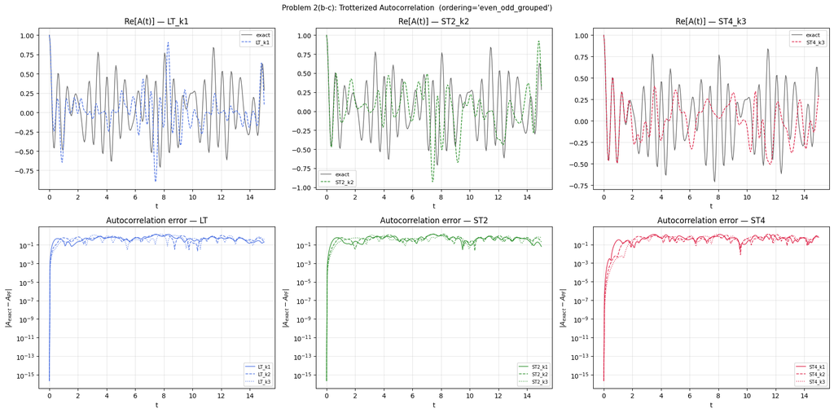

## Problem 2(d-e): Fourier spectrum of A(t)

$$A(t) = \sum_n |\langle E_n|\psi_0\rangle|^2\, e^{-iE_n t}$$

Taking the DFT with convention $\hat{A}(E) = \text{DFT}[A](E)$ using `energy_axis = -2π × freq` (because $A(t) \propto e^{-iEt}$, i.e. negative-frequency convention), the spectrum has peaks **exactly at the eigenenergies $E_n$ for which $|\langle E_n|\psi_0\rangle|^2 > 0$**.

Eigenstates with zero overlap contribute nothing to $A(t)$ for any $t$, so they produce no peak in the Fourier spectrum.

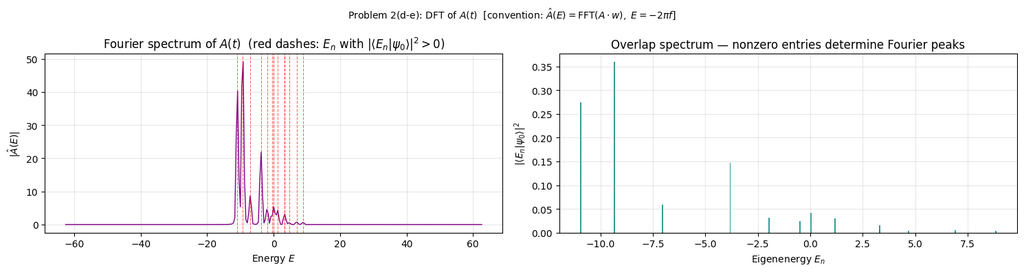

```
Dominant eigenenergies (|⟨E_n|ψ₀⟩|² > threshold):
       E_n     |⟨E_n|ψ₀⟩|²  visible in DFT
   -9.3407          0.3591             YES
  -10.9374          0.2736             YES
   -3.8190          0.1477             YES
   -7.0314          0.0582             YES
    0.0332          0.0414             YES
   -1.9760          0.0317             YES
    1.1652          0.0295             YES
   -0.4966          0.0247             YES
    3.2976          0.0155             YES
    3.2991          0.0055             YES
    6.8991          0.0053             YES
    8.8341          0.0041             YES
    4.6726          0.0037             YES
   -4.1978          0.0000              no
    3.2806          0.0000              no
   -3.9992          0.0000              no
    3.3364          0.0000              no
   -8.3092          0.0000              no
   -0.7194          0.0000              no
   -2.0539          0.0000              no
   -0.1034          0.0000              no
   -3.9992          0.0000              no
   -4.1978          0.0000              no
   -1.7947          0.0000              no
   -3.0401          0.0000              no
    5.6091          0.0000              no
   -0.1034          0.0000              no
    3.3364          0.0000              no
   -3.0401          0.0000              no
   -2.0539          0.0000              no
    3.5972          0.0000              no
    3.9004          0.0000              no
    0.9092          0.0000              no
    5.7198          0.0000              no
   -5.8000          0.0000              no
   -4.9503          0.0000              no
    1.7121          0.0000              no
    1.7121          0.0000              no
```

[output cut: 11 more lines]

```
    3.8405          0.0000              no
    3.8405          0.0000              no
   -4.7115          0.0000              no
    0.9092          0.0000              no
    3.9004          0.0000              no
    2.3556          0.0000              no
    5.6091          0.0000              no
    0.7194          0.0000              no
   -4.9503          0.0000              no
   -1.1732          0.0000              no
   -4.7115          0.0000              no
   -5.7943          0.0000              no
   -1.1732          0.0000              no
   -1.7947          0.0000              no
    4.7115          0.0000              no
```

## Bonus Problem 3: Simple circuit optimization

Compare transpilation optimization levels 0–3 for `SuzukiTrotter(order=2, reps=3)` at $t=0.5$.

```
SuzukiTrotter(order=2, reps=3), t=0.5 — optimization comparison
```

| opt_level | depth | gate count | two-qubit gates |
| --- | --- | --- | --- |
| 0 | 162 | 645 | 216 |
| 1 | 145 | 546 | 216 |
| 2 | 43 | 192 | 63 |
| 3 | 43 | 192 | 63 |

```
Rustiq synthesis not available in this environment.
```